NLP Libraries: 1) NLTK - Natural Language ToolKit 2) Spacy 3) Gensim 4) fastText

# PorterStemmer class

NLTK has PorterStemmer class with the help of which we can easily implement Porter Stemmer algorithms for the word we want to stem. This class knows several regular word forms and suffixes with the help of which it can transform the input word to a final stem. The resulting stem is often a shorter word having the same root meaning.

```python
import nltk
from nltk.stem import PorterStemmer
word_stemmer = PorterStemmer()
word_stemmer.stem('eats')
```

```
'eat'
```

```python
import nltk
from nltk.stem import PorterStemmer
word_stemmer = PorterStemmer()
word_stemmer.stem('Eating')
```

```
'eat'
```

```python
import nltk
from nltk.stem import PorterStemmer
word_stemmer = PorterStemmer()
word_stemmer.stem('Shocking')
```

```
'shock'
```

```python
import nltk
from nltk.stem import PorterStemmer
word_stemmer = PorterStemmer()
word_stemmer.stem('Python Programming')
```

```
'python program'
```

```python
import nltk
from nltk.stem import PorterStemmer
word_stemmer = PorterStemmer()
word_stemmer.stem('Lovable')
```

```
'lovabl'
```

# Python NLTK | nltk.WhitespaceTokenizer:

nltk.tokenize.WhitespaceTokenizer() method, we are able to extract the tokens from string of words or sentences without whitespaces, new line and tabs by using tokenize.WhitespaceTokenizer() method.

```python
# import WhitespaceTokenizer() method from nltk
from nltk.tokenize import WhitespaceTokenizer

# Create a reference variable for Class WhitespaceTokenizer
tk = WhitespaceTokenizer()

# Create a string input
text= "Python \nis\t best %% programming language"
# Use tokenize method
t = tk.tokenize(text)
print(t)
```

```
['Python', 'is', 'best', '%%', 'programming', 'language']
```

```python
# import TabTokenizer() method from nltk
from nltk.tokenize import TabTokenizer

# Create a reference variable for Class TabTokenizer
tk = TabTokenizer()

# Create a string input
text = "NLP for\tNatural..\t.$$&* \nLanguage\t Processing"

# Use tokenize method
t = tk.tokenize(text)

print(t)
```

```
['NLP for', 'Natural..', '.$$&* \nLanguage', ' Processing']
```

nltk.tokenize.WordPunctTokenizer()() method, we are able to extract the tokens from string of words or sentences in the form of Alphabetic and Non-Alphabetic character by using tokenize.WordPunctTokenizer()() method.

```python
# import WordPunctTokenizer() method from nltk
from nltk.tokenize import WordPunctTokenizer
# Create a reference variable for Class WordPunctTokenizer
tk = WordPunctTokenizer()
# Create a string input
txt = "Py*thon...$$&* \nis\t used for Data Science and ML"
# Use tokenize method
t= tk.tokenize(txt)
print(t)
```

```
['Py', '*', 'thon', '...$$&*', 'is', 'used', 'for', 'Data', 'Science', 'and', 'ML']
```

nltk.tokenize.ConditionalFreqDist() method, we are able to count the frequency of words in a sentence by using tokenize.ConditionalFreqDist() method.

```python
# import ConditionalFreqDist() method from nltk
from nltk.probability import ConditionalFreqDist
from nltk.tokenize import word_tokenize
# Create a reference variable for Class SExprTokenizer
tk = ConditionalFreqDist()
# Create a string input
txt = "Python for Python is Best Language Python is Easy To LEarn"
for word in word_tokenize(txt):
    condition = len(word)
    tk[condition][word] += 1
print(tk)
```

```
<ConditionalFreqDist with 6 conditions>
```

```python
import nltk
nltk.download()
```

```
showing info https://raw.githubusercontent.com/nltk/nltk_data/gh-pages/index.xml
```

```
True
```

```python
# import ConditionalFreqDist() method from nltk
from nltk.probability import ConditionalFreqDist
from nltk.tokenize import word_tokenize
# Create a reference variable for Class SExprTokenizer
tk = ConditionalFreqDist()
# Create a string input
txt = "Python for Python is best Language"
for word in word_tokenize(txt):
    condition = len(word)
    tk[condition][word] += 1
print(tk)
tk.tabulate()
```

```
<ConditionalFreqDist with 5 conditions>
  Language   Python     best      for       is
2        0        0        0        0        1
3        0        0        0        1        0
4        0        0        1        0        0
6        0        2        0        0        0
8        1        0        0        0        0
```

# LancasterStemmer class

NLTK has LancasterStemmer class with the help of which we can easily implement Lancaster Stemmer algorithms for the word we want to stem.

```python
import nltk
from nltk.stem import LancatserStemmer
Lanc_stemmer = LancasterStemmer()
Lanc_stemmer.stem('eats')
```

```
---------------------------------------------------------------------------
ImportError                               Traceback (most recent call last)
Cell In[1], line 2
      1 import nltk
----> 2 from nltk.stem import LancatserStemmer
      3 Lanc_stemmer = LancasterStemmer()
      4 Lanc_stemmer.stem('eats')

ImportError: cannot import name 'LancatserStemmer' from 'nltk.stem' (C:\Users\Kani\anaconda3\Lib\site-packages\nltk\stem\__init__.py)
```

```python
import nltk
from nltk.stem import LancasterStemmer
# Initialize the Lancaster Stemmer
Lanc_stemmer = LancasterStemmer()
# List of words to be stemmed
words = ["eats", "eating", "ate", "flies", "flying"]

# Stem each word and print the results
stemmed_words = [Lanc_stemmer.stem(word) for word in words]

for original, stemmed in zip(words, stemmed_words):
    print(f"Original: {original}, Stemmed: {stemmed}")
```

```
Original: eats, Stemmed: eat
Original: eating, Stemmed: eat
Original: ate, Stemmed: at
Original: flies, Stemmed: fli
Original: flying, Stemmed: fly
```

# 14-11-23

```python
import nltk
nltk.download('punkt')
```

```python
help('nltk')
```

[output not shown]

[output cut: 146 more lines]

[output not shown]

```python
import nltk
from nltk import *
sent = "India is a republic nation. We are proud Indians"
```

```python
print(nltk.word_tokenize(sent))
```

```
['India', 'is', 'a', 'republic', 'nation', '.', 'We', 'are', 'proud', 'Indians']
```

```python
tokens = nltk.word_tokenize(sent)
vocab = sorted(set(tokens))
print(vocab)
```

```
['.', 'India', 'Indians', 'We', 'a', 'are', 'is', 'nation', 'proud', 'republic']
```

# Punctuation

Punctuation refers to symbols used to separate sentences and their elements and to clarify meaning.

```python
from string import punctuation
vocab_wo_punct=[]
for i in vocab:
    if i not in punctuation:
        vocab_wo_punct.append(i)
print(vocab_wo_punct)
```

```
['India', 'Indians', 'We', 'a', 'are', 'is', 'nation', 'proud', 'republic']
```

Part of Speech

```python
from nltk import pos_tag
pos_list = pos_tag(vocab_wo_punct)
print(pos_list)
```

```
[('India', 'NNP'), ('Indians', 'NNPS'), ('We', 'PRP'), ('a', 'DT'), ('are', 'VBP'), ('is', 'VBZ'), ('nation', 'NN'), ('proud', 'JJ'), ('republic', 'NN')]
```

Root of a word – Stemming

Stemming is a technique used to find the root form of a word. In the root form, a word is devoid of any affixes (suffixes and prefixes)

```python
from nltk.stem.snowball import SnowballStemmer
stemObj = SnowballStemmer("english")
stemObj.stem("Studying") #Prints 'studi'
stemmed_vocab=[]
stemObj = SnowballStemmer("english")
for i in vocab_wo_punct:
    stemmed_vocab.append(stemObj.stem(i))
print(stemmed_vocab)
```

```
---------------------------------------------------------------------------
NameError                                 Traceback (most recent call last)
Cell In[3], line 6
      4 stemmed_vocab=[]
      5 stemObj = SnowballStemmer("english")
----> 6 for i in vocab_wo_punct:
      7     stemmed_vocab.append(stemObj.stem(i))
      8 print(stemmed_vocab)

NameError: name 'vocab_wo_punct' is not defined
```

Base of a word – Lemmatization

Lemmatization removes inflection and reduces the word to its base form

```python
pip install wordnet
```

```
  Preparing metadata (setup.py): started
  Preparing metadata (setup.py): finished with status 'done'
  Attempting uninstall: colorama
    Found existing installation: colorama 0.4.6
    Uninstalling colorama-0.4.6:
      Successfully uninstalled colorama-0.4.6
```

[output not shown]

```python
pip install WordNetLemmatizer
```

[output not shown]

```python
import nltk
nltk.download('wordnet')
```

```
True
```

```python
from nltk.stem.wordnet import WordNetLemmatizer
lemmaObj =  WordNetLemmatizer()
lemmaObj.lemmatize("went",pos='v')
```

```
'go'
```

```python
from nltk.stem.wordnet import WordNetLemmatizer
lemmaObj =  WordNetLemmatizer()
lemmaObj.lemmatize("ate",pos='v')
```

```
'eat'
```

# Distributions and n-grams

Stop words

Stop words are typically the most commonly occurring words in text like ‘the’, ‘and’, ‘is’, etc. NLTK provides a pre-defined set of stopwords for English

```python
import nltk
nltk.download('stopwords')
```

```
True
```

```python
from nltk.corpus import stopwords
wo_stop_words = []
stop_words_set = set(stopwords.words("english"))
for i in vocab_wo_punct:
    if i not in stop_words_set:
        wo_stop_words.append(i)
print(wo_stop_words)
```

```
['India', 'Indians', 'We', 'nation', 'proud', 'republic']
```

# Frequency Distribution

Frequency distribution helps understand which words are commonly used and which are not. These can help refine stop words in a given text.

```
<FreqDist with 22 samples and 32 outcomes>
```

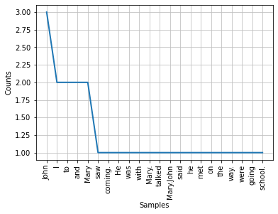

```python
text="I saw John coming. He was with Mary. I talked to John and Mary.John said he met Mary on the way. John and Mary were going to school."
print(nltk.FreqDist(nltk.word_tokenize(text)))
#Prints FreqDist({'.': 5, 'Mary': 4, 'John': 4, 'I': 2, 'to': 2, 'and': 2, 'the': 1, 'was': 1, 'were': 1, 'school': 1, ...})
nltk.FreqDist(text.split()).plot()
```

```python
nltk.FreqDist(text.split())
```

```
FreqDist({'John': 3, 'I': 2, 'to': 2, 'and': 2, 'Mary': 2, 'saw': 1, 'coming.': 1, 'He': 1, 'was': 1, 'with': 1, ...})
```

```python
#Dictionary based Tokenization
from nltk import word_tokenize
from nltk.tokenize import MWETokenizer
dic=[("Jammu","Kashmir"),
    ("Pawan","Kumar","Gautham"),
    ("Himachal","Pradesh")]
dic_token=MWETokenizer(dic,separator='')
print(dic_token)
```

```
<nltk.tokenize.mwe.MWETokenizer object at 0x0000022B5CCB7910>
```

```python
txt="""Jammu Kashmir is an Integral Part of India.
My Name is Pawan Kumar Gautham.
He is from Himachal Pradesh"""
tokens=word_tokenize(txt)
tokens
```

```
['Jammu',
 'Kashmir',
 'is',
 'an',
 'Integral',
 'Part',
 'of',
 'India',
 '.',
 'My',
 'Name',
 'is',
 'Pawan',
 'Kumar',
 'Gautham',
 '.',
 'He',
 'is',
 'from',
 'Himachal',
 'Pradesh']
```

```python
tokens=word_tokenize(txt)
print('General Word Tokenization \n',tokens)
dic_token=dic_token.tokenize(tokens)
print('Dictionary Based Tokenization \n',dic_token)
```

```
General Word Tokenization
 ['Jammu', 'Kashmir', 'is', 'an', 'Integral', 'Part', 'of', 'India', '.', 'My', 'Name', 'is', 'Pawan', 'Kumar', 'Gautham', '.', 'He', 'is', 'from', 'Himachal', 'Pradesh']
Dictionary Based Tokenization
 ['JammuKashmir', 'is', 'an', 'Integral', 'Part', 'of', 'India', '.', 'My', 'Name', 'is', 'PawanKumarGautham', '.', 'He', 'is', 'from', 'HimachalPradesh']
```

```python
from nltk.stem import SnowballStemmer
stemmer=SnowballStemmer(language='english')
words_to_stem=['running','jumped','happily','quickly','foxes']
stemmed_words=[stemmer.stem(word) for word in words_to_stem]
print('Original Words',words_to_stem)
print('Stemmed Words',stemmed_words)
```

```
Original Words ['running', 'jumped', 'happily', 'quickly', 'foxes']
Stemmed Words ['run', 'jump', 'happili', 'quick', 'fox']
```

```python
from nltk.stem import SnowballStemmer
stemmer=SnowballStemmer(language='english')
words_to_stem=['running','jumped','happily','quickly','foxes']
stemmed_words=[stemmer.stem(word) for word in words_to_stem]
print('Original Words',words_to_stem)
print('Stemmed Words',stemmed_words)
```

[output not shown]

```python
import nltk
from nltk.corpus import stopwords
nltk.download('stopwords')
print(stopwords.words('english'))
```

[output not shown]

```python
import spacy
nlp=spacy.load("en_core_web_sm")
txt="There is a pen on the table"
doc=nlp(txt)
filtered_words=[token.text for token in doc if not token.is_stop]
clean_text=' '.join(filtered_words)
print('Original Words:', txt)
print('Text After Stopword Removal:',clean_text)
```

```
Original Words: There is a pen on the table
Text After Stopword Removal: pen table
```